# flightdata2008_3

```python
from IPython.display import HTML
```

```python
HTML('''<script>
code_show=true;
function code_toggle() {
 if (code_show){
 $('div.input').hide();
 } else {
 $('div.input').show();
 }
 code_show = !code_show
}
$( document ).ready(code_toggle);
</script>
The raw code for this IPython notebook is by default hidden for easier reading.
To toggle on/off the raw code, click <a href="javascript:code_toggle()">here</a>.''')
```

The raw code for this IPython notebook is by default hidden for easier reading. To toggle on/off the raw code, click here.

```python
import pandas as pd
import numpy as np
import matplotlib.pyplot as plt
import seaborn as sns
```

```python
#import the data from csv
df=pd.read_csv('fd.csv')
```

```python
#first look on rows and columns
print ((df.shape))
```

```
(2319612, 19)
```

The dataset contains2319612 rows and 19 columns.

```python
print ("There is a total of {} flights in the dataset." .format(len(df.index)))
```

```
There is a total of 2319612 flights in the dataset.
```

```python
df.info()
```

```
<class 'pandas.core.frame.DataFrame'>
RangeIndex: 2319612 entries, 0 to 2319611
Data columns (total 19 columns):
Year                int64
Month               int64
DayofMonth          int64
DayOfWeek           int64
UniqueCarrier       object
Origin              object
Dest                object
Distance            int64
Cancelled           int64
CancellationCode    object
Code                object
Description         object
iata                object
airport             object
city                object
state               object
country             object
lat                 float64
long                float64
dtypes: float64(2), int64(6), object(11)
memory usage: 238.9+ MB
```

```python
df.head()
```

|  | Year | Month | DayofMonth | DayOfWeek | UniqueCarrier | Origin | Dest | Distance | Cancelled | CancellationCode | Code | Description | iata | airport | city | state | country | lat | long |
| --- | --- | --- | --- | --- | --- | --- | --- | --- | --- | --- | --- | --- | --- | --- | --- | --- | --- | --- | --- |
| 0 | 2008 | 1 | 1 | 2 | XE | EWR | MYR | 550 | 0 | NaN | XE | Expressjet Airlines Inc. | EWR | Newark Intl | Newark | NJ | USA | 40.692497 | -74.168661 |
| 1 | 2008 | 1 | 1 | 2 | XE | AUS | ONT | 1197 | 0 | NaN | XE | Expressjet Airlines Inc. | AUS | Austin-Bergstrom International | Austin | TX | USA | 30.194533 | -97.669872 |
| 2 | 2008 | 1 | 1 | 2 | XE | ONT | MCI | 1318 | 0 | NaN | XE | Expressjet Airlines Inc. | ONT | Ontario International | Ontario | CA | USA | 34.056000 | -117.601194 |
| 3 | 2008 | 1 | 1 | 2 | XE | FAT | ONT | 222 | 0 | NaN | XE | Expressjet Airlines Inc. | FAT | Fresno Yosemite International | Fresno | CA | USA | 36.776194 | -119.718139 |
| 4 | 2008 | 1 | 1 | 2 | XE | ONT | ELP | 670 | 0 | NaN | XE | Expressjet Airlines Inc. | ONT | Ontario International | Ontario | CA | USA | 34.056000 | -117.601194 |

```python
#is any row null?
df.isnull().any()
```

```
Year                False
Month               False
DayofMonth          False
DayOfWeek           False
UniqueCarrier       False
Origin              False
Dest                False
Distance            False
Cancelled           False
CancellationCode     True
Code                False
Description         False
iata                False
airport             False
city                 True
state                True
country             False
lat                 False
long                False
dtype: bool
```

The data contains Null values in the columns Cancellation Code, city and state. This is acceptable for the intended purpose so I will keep them.

```python
df.describe().transpose()
```

|  | count | mean | std | min | 25% | 50% | 75% | max |
| --- | --- | --- | --- | --- | --- | --- | --- | --- |
| Year | 2319612.0 | 2008.000000 | 0.000000 | 2008.000000 | 2008.000000 | 2008.000000 | 2008.000000 | 2008.000000 |
| Month | 2319612.0 | 6.343666 | 3.433463 | 1.000000 | 3.000000 | 6.000000 | 9.000000 | 12.000000 |
| DayofMonth | 2319612.0 | 15.727206 | 8.807478 | 1.000000 | 8.000000 | 16.000000 | 23.000000 | 31.000000 |
| DayOfWeek | 2319612.0 | 3.979993 | 1.997027 | 1.000000 | 2.000000 | 4.000000 | 6.000000 | 7.000000 |
| Distance | 2319612.0 | 812.030221 | 622.321614 | 11.000000 | 365.000000 | 640.000000 | 1034.000000 | 4962.000000 |
| Cancelled | 2319612.0 | 0.047514 | 0.212735 | 0.000000 | 0.000000 | 0.000000 | 0.000000 | 1.000000 |
| lat | 2319612.0 | 37.206219 | 5.924640 | 17.701889 | 33.640444 | 38.533963 | 41.066958 | 71.285448 |
| long | 2319612.0 | -93.902916 | 17.520690 | -176.646031 | -104.667002 | -87.904464 | -81.316028 | -64.798556 |

To summarize the first investigation, the data is very tidy and can easily be used for further analyis.

```python
#accessing the first data entry to see if there is any strange data to be seen
print (df.iloc [358])
```

```
Year                                        2008
Month                                          1
DayofMonth                                     1
DayOfWeek                                      2
UniqueCarrier                                 XE
Origin                                       IAH
Dest                                         BRO
Distance                                     308
Cancelled                                      0
CancellationCode                             NaN
Code                                          XE
Description             Expressjet Airlines Inc.
iata                                         IAH
airport             George Bush Intercontinental
city                                     Houston
state                                         TX
country                                      USA
lat                                      29.9805
long                                    -95.3397
Name: 358, dtype: object
```

The Cancelation Code contains not NaN values. This needs to be fixed.

```python
# replace NaN values
df.replace(np.nan, 0, inplace=True)
```

```python
print (df.iloc [358])
```

```
Year                                        2008
Month                                          1
DayofMonth                                     1
DayOfWeek                                      2
UniqueCarrier                                 XE
Origin                                       IAH
Dest                                         BRO
Distance                                     308
Cancelled                                      0
CancellationCode                               0
Code                                          XE
Description             Expressjet Airlines Inc.
iata                                         IAH
airport             George Bush Intercontinental
city                                     Houston
state                                         TX
country                                      USA
lat                                      29.9805
long                                    -95.3397
Name: 358, dtype: object
```

Ok, looks good now. After I was using fillna I still got NaN, replace is the better choice in this case.

### Investigation on the questions:

```
What are the airliners with the least cancellations?
Which airports are the busiest ones?
Is there a timly insight on flight frequency over the months?
```

```python
# What is the proportion of cancelled flights to all flights?
print("the proportion of all canceled flight to all flights is:")
print(len(df[df.Cancelled != 0]) / float(len(df)))
```

```
the proportion of all canceled flight to all flights is:
0.047513549679860254
```

```python
# Trimming the value for US Airways - parentheses to be killed
def remove_parenthetical_description(description):
    return description.split(' (')[0]

df.Description = df.Description.map(remove_parenthetical_description)

#check if the code worked
#df[df.Code == 'US']
```

I have deleted the information for US Airways in parentheses as the info is not needed for the analyis. And it looks better now.

```python
#df_a = df.groupby(by=['Description'])
#df_ag= (grouped_carrier_g['Cancelled'].sum() / grouped_carrier_g.size())

#monthly_flights = df.groupby(by=['Description', 'Month'])
monthly_flights = df.groupby(by=['Description'])
g =monthly_flights.size()
flights =monthly_flights.size()
flights
```

```
Description
AirTran Airways Corporation      92360
Alaska Airlines Inc.             51900
Aloha Airlines Inc.               2113
American Airlines Inc.          156409
American Eagle Airlines Inc.    145006
Atlantic Southeast Airlines      96787
Comair Inc.                      97329
Continental Air Lines Inc.       80488
Delta Air Lines Inc.            133924
Expressjet Airlines Inc.        157253
Frontier Airlines Inc.           28876
Hawaiian Airlines Inc.           14032
JetBlue Airways                  81784
Mesa Airlines Inc.              116634
Northwest Airlines Inc.         121188
Pinnacle Airlines Inc.          140286
Skywest Airlines Inc.           208786
Southwest Airlines Co.          320910
US Airways Inc.                 139371
United Air Lines Inc.           134176
dtype: int64
```

```python
grouped_carrier_g = df.groupby(by=['Description'])
proportional_cancellations_g = (grouped_carrier_g['Cancelled'].sum() / grouped_carrier_g.size())
proportional_cancellations_g
```

```
Description
AirTran Airways Corporation     0.021146
Alaska Airlines Inc.            0.034509
Aloha Airlines Inc.             0.018930
American Airlines Inc.          0.077419
American Eagle Airlines Inc.    0.098927
Atlantic Southeast Airlines     0.044458
Comair Inc.                     0.056807
Continental Air Lines Inc.      0.029433
Delta Air Lines Inc.            0.040082
Expressjet Airlines Inc.        0.048069
Frontier Airlines Inc.          0.008415
Hawaiian Airlines Inc.          0.023446
JetBlue Airways                 0.033992
Mesa Airlines Inc.              0.071780
Northwest Airlines Inc.         0.021091
Pinnacle Airlines Inc.          0.047517
Skywest Airlines Inc.           0.049999
Southwest Airlines Co.          0.027653
US Airways Inc.                 0.039248
United Air Lines Inc.           0.067956
dtype: float64
```

I have calculated the proportional cancellation rate per carrier as well as the flights per carrier.

```python
dframes = [flights, proportional_cancellations_g]
df_flightdata = pd.concat(dframes, axis=1)

df_flightdata ['flights']= df_flightdata[0]
df_flightdata ['can_rate']= df_flightdata[1]

df_flightdata.pop (0)
df_flightdata.pop (1)
df_flightdata
```

| Description | flights | can_rate |
| --- | --- | --- |
| AirTran Airways Corporation | 92360 | 0.021146 |
| Alaska Airlines Inc. | 51900 | 0.034509 |
| Aloha Airlines Inc. | 2113 | 0.018930 |
| American Airlines Inc. | 156409 | 0.077419 |
| American Eagle Airlines Inc. | 145006 | 0.098927 |
| Atlantic Southeast Airlines | 96787 | 0.044458 |
| Comair Inc. | 97329 | 0.056807 |
| Continental Air Lines Inc. | 80488 | 0.029433 |
| Delta Air Lines Inc. | 133924 | 0.040082 |
| Expressjet Airlines Inc. | 157253 | 0.048069 |
| Frontier Airlines Inc. | 28876 | 0.008415 |
| Hawaiian Airlines Inc. | 14032 | 0.023446 |
| JetBlue Airways | 81784 | 0.033992 |
| Mesa Airlines Inc. | 116634 | 0.071780 |
| Northwest Airlines Inc. | 121188 | 0.021091 |
| Pinnacle Airlines Inc. | 140286 | 0.047517 |
| Skywest Airlines Inc. | 208786 | 0.049999 |
| Southwest Airlines Co. | 320910 | 0.027653 |
| US Airways Inc. | 139371 | 0.039248 |
| United Air Lines Inc. | 134176 | 0.067956 |

```python
df_flightdata.to_csv('flightdata.csv')
```

```python
df_flightdata.to_json(orient='index')
df_flightdata.to_json("/Users/tha278/Desktop/test.JSON")
```

## Visualisation of the Cancellation Rate per Carrier in 2008 / US

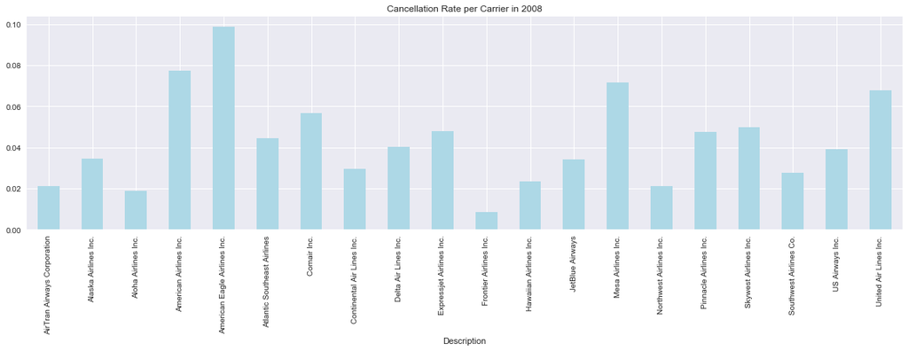

```python
# visualization of cancellation rate per Carrier
proportional_cancellations_g.plot(kind='bar', stacked=False,color ='lightblue', figsize=[20,5],title ="Cancellation Rate per Carrier in 2008")
plt.show()
```

### Calculation of the cancellation Reasons per Month and visualisation

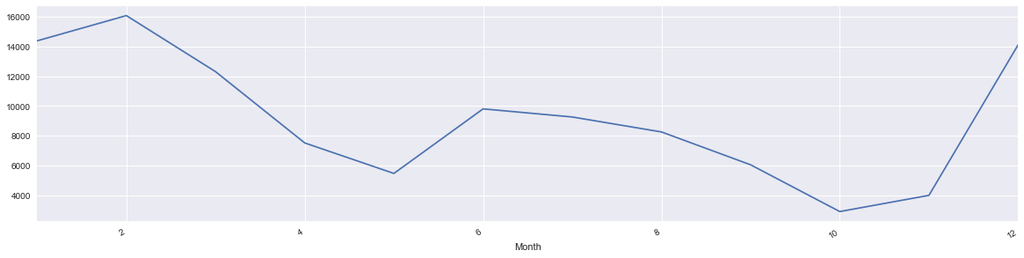

```python
# Cancellations by month.
grouped_carrier = df.groupby(by=[ 'Month'])
sum_cancellations = grouped_carrier['Cancelled'].sum()
sum_cancellations.plot(subplots=True, figsize=(20,5))
plt.show()
```

```python
def getCodes(dataFrame):
    result = {}
    for month in range(1,13):
        preDF = dataFrame[dataFrame['Month'] == month]
        result[month] = {}
        result[month]['A'] = len(preDF[preDF['CancellationCode'] == 'A'])
        result[month]['B'] = len(preDF[preDF['CancellationCode'] == 'B'])
        result[month]['C'] = len(preDF[preDF['CancellationCode'] == 'C'])
        result[month]['D'] = len(preDF[preDF['CancellationCode'] == 'D'])
    return pd.DataFrame().from_dict(result, orient= 'index')

codeDF = getCodes(df)
codeDF
```

|  | A | B | C | D |
| --- | --- | --- | --- | --- |
| 1 | 6106 | 5080 | 3181 | 0 |
| 2 | 5693 | 6773 | 3587 | 2 |
| 3 | 5395 | 4719 | 2184 | 4 |
| 4 | 4890 | 1277 | 1364 | 0 |
| 5 | 2980 | 1158 | 1348 | 3 |
| 6 | 4023 | 2974 | 2813 | 0 |
| 7 | 4763 | 2220 | 2285 | 0 |
| 8 | 3653 | 2703 | 1911 | 0 |
| 9 | 2110 | 2966 | 990 | 1 |
| 10 | 1947 | 522 | 468 | 0 |
| 11 | 2295 | 834 | 891 | 2 |
| 12 | 4441 | 7178 | 2479 | 0 |

### Cancellation Reasons per Month

From this graph, we see a trend to increasing cancellation rate during the summer and winter holiday season. It would be nice to investigate on the reasons behind the cancellations.

There is a clear peak in the cancellation rate in the winter month, which is reasonable. Bad weather with Ice and Snow can lead to a high cancellation rate. Whereas the light peak in June needs to be further investigated.

The assumption of bad weather having influence on the cancellation rate in winter looks as if it is highly correlated to the winter months. Whereas the peak in summer is more due carrier reasons whatever that means, weather and NAS are involved as well wehreas security reasons influence is nearly Null.

A = carrier, B= weather, C=NAS, D = security

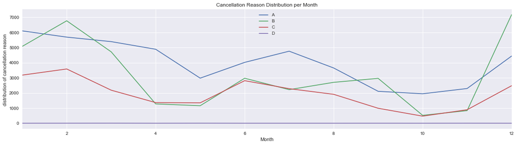

```python
codeDF.plot(subplots=False, figsize=(20,5))
plt.ylabel('distribution of cancellation reason ')
plt.xlabel('Month')
plt.title('Cancellation Reason Distribution per Month')
plt.show()
```

Additional information provied for the breakdown on Airline Cancellation Codes in the following code snippet. A dictionary per Airline is delivered containing the Cancellation reasons.

```python
# Cancellations by carrier and month.
def getCodesWithAirline(dataFrame):
    result = {}
    for month in range(1,13):
        preDF1 = dataFrame[dataFrame['Month'] == month]
        result[month] = {}
        for airline in set(preDF1['Description']):
            result[month][airline] = {}
            preDF2 = preDF1[preDF1['Description'] == airline]

            result[month][airline]['A'] = len(preDF2[preDF2['CancellationCode'] == 'A'])
            result[month][airline]['B'] = len(preDF2[preDF2['CancellationCode'] == 'B'])
            result[month][airline]['C'] = len(preDF2[preDF2['CancellationCode'] == 'C'])
            result[month][airline]['D'] = len(preDF2[preDF2['CancellationCode'] == 'D'])
    return pd.DataFrame().from_dict(result, orient='index')

airline_code= getCodesWithAirline(df)
airline_code
```

|  | American Airlines Inc. | Skywest Airlines Inc. | American Eagle Airlines Inc. | Southwest Airlines Co. | Comair Inc. | Hawaiian Airlines Inc. | Pinnacle Airlines Inc. | Frontier Airlines Inc. | Continental Air Lines Inc. | United Air Lines Inc. | Atlantic Southeast Airlines | JetBlue Airways | Mesa Airlines Inc. | Expressjet Airlines Inc. | Northwest Airlines Inc. | US Airways Inc. | AirTran Airways Corporation | Delta Air Lines Inc. | Alaska Airlines Inc. | Aloha Airlines Inc. |
| --- | --- | --- | --- | --- | --- | --- | --- | --- | --- | --- | --- | --- | --- | --- | --- | --- | --- | --- | --- | --- |
| 1 | {'A': 750, 'B': 287, 'C': 376, 'D': 0} | {'A': 440, 'B': 587, 'C': 955, 'D': 0} | {'A': 441, 'B': 709, 'C': 776, 'D': 0} | {'A': 617, 'B': 248, 'C': 89, 'D': 0} | {'A': 174, 'B': 267, 'C': 0, 'D': 0} | {'A': 27, 'B': 0, 'C': 0, 'D': 0} | {'A': 718, 'B': 268, 'C': 70, 'D': 0} | {'A': 3, 'B': 9, 'C': 0, 'D': 0} | {'A': 30, 'B': 125, 'C': 4, 'D': 0} | {'A': 796, 'B': 275, 'C': 166, 'D': 0} | {'A': 134, 'B': 764, 'C': 5, 'D': 0} | {'A': 175, 'B': 0, 'C': 0, 'D': 0} | {'A': 750, 'B': 306, 'C': 261, 'D': 0} | {'A': 74, 'B': 235, 'C': 231, 'D': 0} | {'A': 75, 'B': 105, 'C': 62, 'D': 0} | {'A': 334, 'B': 86, 'C': 117, 'D': 0} | {'A': 51, 'B': 144, 'C': 19, 'D': 0} | {'A': 271, 'B': 578, 'C': 31, 'D': 0} | {'A': 223, 'B': 87, 'C': 19, 'D': 0} | {'A': 23, 'B': 0, 'C': 0, 'D': 0} |
| 2 | {'A': 672, 'B': 652, 'C': 343, 'D': 0} | {'A': 337, 'B': 572, 'C': 751, 'D': 0} | {'A': 447, 'B': 894, 'C': 794, 'D': 0} | {'A': 591, 'B': 565, 'C': 88, 'D': 0} | {'A': 124, 'B': 713, 'C': 7, 'D': 0} | {'A': 11, 'B': 0, 'C': 0, 'D': 0} | {'A': 647, 'B': 414, 'C': 115, 'D': 0} | {'A': 3, 'B': 26, 'C': 0, 'D': 0} | {'A': 52, 'B': 227, 'C': 1, 'D': 0} | {'A': 460, 'B': 481, 'C': 230, 'D': 0} | {'A': 193, 'B': 282, 'C': 53, 'D': 2} | {'A': 29, 'B': 260, 'C': 0, 'D': 0} | {'A': 1224, 'B': 342, 'C': 378, 'D': 0} | {'A': 73, 'B': 583, 'C': 379, 'D': 0} | {'A': 131, 'B': 183, 'C': 149, 'D': 0} | {'A': 299, 'B': 124, 'C': 149, 'D': 0} | {'A': 72, 'B': 148, 'C': 28, 'D': 0} | {'A': 181, 'B': 245, 'C': 110, 'D': 0} | {'A': 130, 'B': 62, 'C': 12, 'D': 0} | {'A': 17, 'B': 0, 'C': 0, 'D': 0} |
| 3 | {'A': 784, 'B': 702, 'C': 161, 'D': 0} | {'A': 366, 'B': 391, 'C': 384, 'D': 0} | {'A': 375, 'B': 878, 'C': 421, 'D': 4} | {'A': 436, 'B': 217, 'C': 33, 'D': 0} | {'A': 184, 'B': 467, 'C': 3, 'D': 0} | {'A': 16, 'B': 0, 'C': 0, 'D': 0} | {'A': 743, 'B': 200, 'C': 156, 'D': 0} | {'A': 6, 'B': 25, 'C': 0, 'D': 0} | {'A': 89, 'B': 170, 'C': 14, 'D': 0} | {'A': 541, 'B': 217, 'C': 64, 'D': 0} | {'A': 197, 'B': 119, 'C': 118, 'D': 0} | {'A': 64, 'B': 96, 'C': 26, 'D': 0} | {'A': 333, 'B': 112, 'C': 209, 'D': 0} | {'A': 210, 'B': 715, 'C': 306, 'D': 0} | {'A': 172, 'B': 84, 'C': 70, 'D': 0} | {'A': 358, 'B': 58, 'C': 83, 'D': 0} | {'A': 74, 'B': 102, 'C': 38, 'D': 0} | {'A': 377, 'B': 155, 'C': 94, 'D': 0} | {'A': 70, 'B': 11, 'C': 4, 'D': 0} | NaN |
| 4 | {'A': 1542, 'B': 105, 'C': 71, 'D': 0} | {'A': 294, 'B': 189, 'C': 157, 'D': 0} | {'A': 275, 'B': 305, 'C': 326, 'D': 0} | {'A': 461, 'B': 0, 'C': 19, 'D': 0} | {'A': 74, 'B': 163, 'C': 15, 'D': 0} | {'A': 13, 'B': 0, 'C': 0, 'D': 0} | {'A': 373, 'B': 57, 'C': 64, 'D': 0} | {'A': 7, 'B': 0, 'C': 0, 'D': 0} | {'A': 48, 'B': 32, 'C': 4, 'D': 0} | {'A': 458, 'B': 122, 'C': 44, 'D': 0} | {'A': 29, 'B': 17, 'C': 68, 'D': 0} | {'A': 43, 'B': 53, 'C': 28, 'D': 0} | {'A': 405, 'B': 84, 'C': 218, 'D': 0} | {'A': 30, 'B': 49, 'C': 196, 'D': 0} | {'A': 118, 'B': 29, 'C': 49, 'D': 0} | {'A': 306, 'B': 18, 'C': 42, 'D': 0} | {'A': 81, 'B': 8, 'C': 31, 'D': 0} | {'A': 210, 'B': 25, 'C': 32, 'D': 0} | {'A': 123, 'B': 21, 'C': 0, 'D': 0} | NaN |
| 5 | {'A': 570, 'B': 271, 'C': 97, 'D': 2} | {'A': 153, 'B': 88, 'C': 168, 'D': 0} | {'A': 314, 'B': 361, 'C': 334, 'D': 0} | {'A': 291, 'B': 16, 'C': 27, 'D': 0} | {'A': 34, 'B': 138, 'C': 0, 'D': 0} | {'A': 11, 'B': 0, 'C': 0, 'D': 0} | {'A': 133, 'B': 45, 'C': 14, 'D': 1} | {'A': 7, 'B': 2, 'C': 0, 'D': 0} | {'A': 39, 'B': 29, 'C': 6, 'D': 0} | {'A': 492, 'B': 57, 'C': 110, 'D': 0} | {'A': 51, 'B': 0, 'C': 5, 'D': 0} | {'A': 12, 'B': 12, 'C': 2, 'D': 0} | {'A': 288, 'B': 27, 'C': 136, 'D': 0} | {'A': 29, 'B': 69, 'C': 274, 'D': 0} | {'A': 80, 'B': 13, 'C': 29, 'D': 0} | {'A': 230, 'B': 8, 'C': 73, 'D': 0} | {'A': 67, 'B': 12, 'C': 25, 'D': 0} | {'A': 74, 'B': 4, 'C': 48, 'D': 0} | {'A': 105, 'B': 6, 'C': 0, 'D': 0} | NaN |
| 6 | {'A': 340, 'B': 382, 'C': 166, 'D': 0} | {'A': 255, 'B': 248, 'C': 388, 'D': 0} | {'A': 333, 'B': 648, 'C': 564, 'D': 0} | {'A': 242, 'B': 12, 'C': 31, 'D': 0} | {'A': 117, 'B': 469, 'C': 4, 'D': 0} | {'A': 15, 'B': 0, 'C': 0, 'D': 0} | {'A': 193, 'B': 65, 'C': 84, 'D': 0} | {'A': 15, 'B': 4, 'C': 0, 'D': 0} | {'A': 107, 'B': 103, 'C': 4, 'D': 0} | {'A': 721, 'B': 213, 'C': 150, 'D': 0} | {'A': 106, 'B': 5, 'C': 37, 'D': 0} | {'A': 50, 'B': 285, 'C': 21, 'D': 0} | {'A': 434, 'B': 82, 'C': 368, 'D': 0} | {'A': 63, 'B': 301, 'C': 539, 'D': 0} | {'A': 219, 'B': 47, 'C': 124, 'D': 0} | {'A': 389, 'B': 44, 'C': 193, 'D': 0} | {'A': 75, 'B': 16, 'C': 47, 'D': 0} | {'A': 267, 'B': 33, 'C': 93, 'D': 0} | {'A': 82, 'B': 17, 'C': 0, 'D': 0} | NaN |
| 7 | {'A': 482, 'B': 152, 'C': 113, 'D': 0} | {'A': 368, 'B': 91, 'C': 164, 'D': 0} | {'A': 339, 'B': 189, 'C': 462, 'D': 0} | {'A': 398, 'B': 51, 'C': 65, 'D': 0} | {'A': 200, 'B': 513, 'C': 6, 'D': 0} | {'A': 41, 'B': 0, 'C': 0, 'D': 0} | {'A': 163, 'B': 25, 'C': 97, 'D': 0} | {'A': 13, 'B': 4, 'C': 0, 'D': 0} | {'A': 130, 'B': 111, 'C': 21, 'D': 0} | {'A': 973, 'B': 151, 'C': 55, 'D': 0} | {'A': 139, 'B': 50, 'C': 436, 'D': 0} | {'A': 100, 'B': 358, 'C': 9, 'D': 0} | {'A': 292, 'B': 25, 'C': 193, 'D': 0} | {'A': 40, 'B': 66, 'C': 307, 'D': 0} | {'A': 78, 'B': 32, 'C': 70, 'D': 0} | {'A': 396, 'B': 68, 'C': 121, 'D': 0} | {'A': 157, 'B': 72, 'C': 36, 'D': 0} | {'A': 382, 'B': 246, 'C': 122, 'D': 0} | {'A': 72, 'B': 16, 'C': 8, 'D': 0} | NaN |
| 8 | {'A': 671, 'B': 244, 'C': 125, 'D': 0} | {'A': 154, 'B': 127, 'C': 82, 'D': 0} | {'A': 263, 'B': 264, 'C': 417, 'D': 0} | {'A': 286, 'B': 174, 'C': 15, 'D': 0} | {'A': 134, 'B': 534, 'C': 8, 'D': 0} | {'A': 33, 'B': 0, 'C': 0, 'D': 0} | {'A': 112, 'B': 38, 'C': 19, 'D': 0} | {'A': 5, 'B': 19, 'C': 0, 'D': 0} | {'A': 57, 'B': 106, 'C': 6, 'D': 0} | {'A': 538, 'B': 155, 'C': 61, 'D': 0} | {'A': 189, 'B': 97, 'C': 195, 'D': 0} | {'A': 53, 'B': 407, 'C': 2, 'D': 0} | {'A': 284, 'B': 20, 'C': 113, 'D': 0} | {'A': 104, 'B': 268, 'C': 477, 'D': 0} | {'A': 59, 'B': 20, 'C': 46, 'D': 0} | {'A': 307, 'B': 94, 'C': 131, 'D': 0} | {'A': 66, 'B': 45, 'C': 40, 'D': 0} | {'A': 243, 'B': 51, 'C': 174, 'D': 0} | {'A': 95, 'B': 40, 'C': 0, 'D': 0} | NaN |
| 9 | {'A': 316, 'B': 148, 'C': 58, 'D': 0} | {'A': 133, 'B': 123, 'C': 120, 'D': 1} | {'A': 216, 'B': 269, 'C': 272, 'D': 0} | {'A': 406, 'B': 604, 'C': 43, 'D': 0} | {'A': 37, 'B': 233, 'C': 11, 'D': 0} | {'A': 9, 'B': 0, 'C': 0, 'D': 0} | {'A': 110, 'B': 67, 'C': 35, 'D': 0} | {'A': 8, 'B': 9, 'C': 0, 'D': 0} | {'A': 40, 'B': 390, 'C': 1, 'D': 0} | {'A': 177, 'B': 82, 'C': 36, 'D': 0} | {'A': 27, 'B': 82, 'C': 10, 'D': 0} | {'A': 10, 'B': 127, 'C': 0, 'D': 0} | {'A': 150, 'B': 50, 'C': 83, 'D': 0} | {'A': 18, 'B': 533, 'C': 109, 'D': 0} | {'A': 34, 'B': 21, 'C': 45, 'D': 0} | {'A': 193, 'B': 72, 'C': 68, 'D': 0} | {'A': 40, 'B': 46, 'C': 26, 'D': 0} | {'A': 141, 'B': 91, 'C': 73, 'D': 0} | {'A': 45, 'B': 19, 'C': 0, 'D': 0} | NaN |
| 10 | {'A': 235, 'B': 8, 'C': 43, 'D': 0} | {'A': 112, 'B': 110, 'C': 43, 'D': 0} | {'A': 113, 'B': 57, 'C': 95, 'D': 0} | {'A': 432, 'B': 49, 'C': 50, 'D': 0} | {'A': 6, 'B': 42, 'C': 0, 'D': 0} | {'A': 22, 'B': 1, 'C': 0, 'D': 0} | {'A': 128, 'B': 8, 'C': 7, 'D': 0} | {'A': 14, 'B': 0, 'C': 0, 'D': 0} | {'A': 28, 'B': 23, 'C': 6, 'D': 0} | {'A': 187, 'B': 19, 'C': 18, 'D': 0} | {'A': 40, 'B': 19, 'C': 21, 'D': 0} | {'A': 13, 'B': 37, 'C': 0, 'D': 0} | {'A': 171, 'B': 28, 'C': 9, 'D': 0} | {'A': 2, 'B': 68, 'C': 64, 'D': 0} | {'A': 29, 'B': 0, 'C': 11, 'D': 0} | {'A': 180, 'B': 9, 'C': 38, 'D': 0} | {'A': 22, 'B': 4, 'C': 31, 'D': 0} | {'A': 153, 'B': 14, 'C': 30, 'D': 0} | {'A': 60, 'B': 26, 'C': 2, 'D': 0} | NaN |
| 11 | {'A': 248, 'B': 79, 'C': 37, 'D': 0} | {'A': 114, 'B': 173, 'C': 122, 'D': 0} | {'A': 101, 'B': 87, 'C': 165, 'D': 0} | {'A': 588, 'B': 46, 'C': 83, 'D': 2} | {'A': 22, 'B': 127, 'C': 2, 'D': 0} | {'A': 44, 'B': 0, 'C': 0, 'D': 0} | {'A': 217, 'B': 46, 'C': 12, 'D': 0} | {'A': 12, 'B': 5, 'C': 0, 'D': 0} | {'A': 15, 'B': 8, 'C': 4, 'D': 0} | {'A': 196, 'B': 27, 'C': 21, 'D': 0} | {'A': 64, 'B': 29, 'C': 58, 'D': 0} | {'A': 20, 'B': 90, 'C': 0, 'D': 0} | {'A': 150, 'B': 58, 'C': 33, 'D': 0} | {'A': 6, 'B': 8, 'C': 188, 'D': 0} | {'A': 32, 'B': 5, 'C': 11, 'D': 0} | {'A': 207, 'B': 11, 'C': 54, 'D': 0} | {'A': 37, 'B': 16, 'C': 27, 'D': 0} | {'A': 173, 'B': 7, 'C': 70, 'D': 0} | {'A': 49, 'B': 12, 'C': 4, 'D': 0} | NaN |
| 12 | {'A': 384, 'B': 324, 'C': 169, 'D': 0} | {'A': 376, 'B': 905, 'C': 398, 'D': 0} | {'A': 298, 'B': 996, 'C': 543, 'D': 0} | {'A': 826, 'B': 718, 'C': 55, 'D': 0} | {'A': 190, 'B': 465, 'C': 46, 'D': 0} | {'A': 82, 'B': 4, 'C': 0, 'D': 0} | {'A': 648, 'B': 449, 'C': 125, 'D': 0} | {'A': 15, 'B': 30, 'C': 2, 'D': 0} | {'A': 79, 'B': 253, 'C': 7, 'D': 0} | {'A': 252, 'B': 485, 'C': 88, 'D': 0} | {'A': 194, 'B': 253, 'C': 215, 'D': 0} | {'A': 56, 'B': 336, 'C': 6, 'D': 0} | {'A': 232, 'B': 331, 'C': 193, 'D': 0} | {'A': 15, 'B': 627, 'C': 303, 'D': 0} | {'A': 73, 'B': 182, 'C': 69, 'D': 0} | {'A': 337, 'B': 185, 'C': 88, 'D': 0} | {'A': 42, 'B': 167, 'C': 41, 'D': 0} | {'A': 245, 'B': 196, 'C': 129, 'D': 0} | {'A': 97, 'B': 272, 'C': 2, 'D': 0} | NaN |

### Evaluation of the no of flights by Month

```python
# no of flights
monthly_flights = df.groupby(by=['Month'])
g =monthly_flights.size()
#g
```

```python
# monthly cancellation rate
grouped_m = df.groupby(by=['Month'])
prop_m = (grouped_m['Cancelled'].sum() / grouped_m.size())
#prop_m
```

```python
frames = [g, prop_m]
df42 = pd.concat(frames, axis=1)
df42['flights']= df42[0]
df42['can_rate']= df42[1]
#df42.drop('month')
df42.pop (0)
df42.pop (1)
df42
```

| Month | flights | can_rate |
| --- | --- | --- |
| 1 | 207605 | 0.069204 |
| 2 | 195645 | 0.082062 |
| 3 | 207057 | 0.059414 |
| 4 | 193738 | 0.038872 |
| 5 | 197939 | 0.027731 |
| 6 | 199699 | 0.049124 |
| 7 | 205536 | 0.045092 |
| 8 | 201651 | 0.040997 |
| 9 | 174747 | 0.034719 |
| 10 | 176549 | 0.016636 |
| 11 | 171588 | 0.023440 |
| 12 | 187858 | 0.075046 |

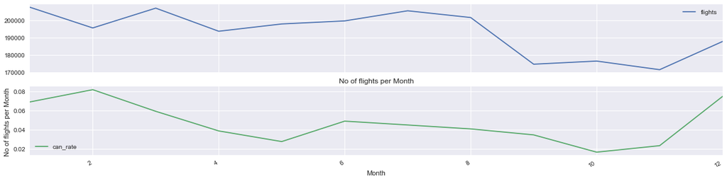

```python
df42.plot(subplots=True, figsize=(20,5))
plt.ylabel('No of flights per Month ')
plt.xlabel('Month')
plt.title('No of flights per Month')
plt.show()
```

### Calculation of airport departures

```python
#airport view - Top 10 Airports  Departures
dest = df.groupby(by=['Origin'])
d =dest.size()
d.sort_values (ascending = False)[:10]
```

```
Origin
ATL    114718
ORD    112165
DEN     79867
DFW     62758
DTW     58419
PHX     57092
IAH     54906
LAX     52796
SLC     51591
LAS     50023
dtype: int64
```

### Calculation of Airport Arrivals

```python
#airport view - Top 10 Airports Arrivals
dest = df.groupby(by=['Dest'])
d2 =dest.size()
d2.sort_values (ascending = False)[:10]
```

```
Dest
ATL    115557
ORD    112556
DEN     79805
DFW     63180
DTW     58362
PHX     57814
IAH     55045
LAX     53022
SLC     51808
MSP     50065
dtype: int64
```

```python
airport_data= pd.read_csv('airports.csv')
```

```python
airport_data
```

|  | iata | airport | city | state | country | lat | long |
| --- | --- | --- | --- | --- | --- | --- | --- |
| 0 | 00M | Thigpen | Bay Springs | MS | USA | 31.953765 | -89.234505 |
| 1 | 00R | Livingston Municipal | Livingston | TX | USA | 30.685861 | -95.017928 |
| 2 | 00V | Meadow Lake | Colorado Springs | CO | USA | 38.945749 | -104.569893 |
| 3 | 01G | Perry-Warsaw | Perry | NY | USA | 42.741347 | -78.052081 |
| 4 | 01J | Hilliard Airpark | Hilliard | FL | USA | 30.688012 | -81.905944 |
| 5 | 01M | Tishomingo County | Belmont | MS | USA | 34.491667 | -88.201111 |
| 6 | 02A | Gragg-Wade | Clanton | AL | USA | 32.850487 | -86.611453 |
| 7 | 02C | Capitol | Brookfield | WI | USA | 43.087510 | -88.177869 |
| 8 | 02G | Columbiana County | East Liverpool | OH | USA | 40.673313 | -80.641406 |
| 9 | 03D | Memphis Memorial | Memphis | MO | USA | 40.447259 | -92.226961 |
| 10 | 04M | Calhoun County | Pittsboro | MS | USA | 33.930112 | -89.342852 |
| 11 | 04Y | Hawley Municipal | Hawley | MN | USA | 46.883849 | -96.350899 |
| 12 | 05C | Griffith-Merrillville | Griffith | IN | USA | 41.519619 | -87.401093 |
| 13 | 05F | Gatesville - City/County | Gatesville | TX | USA | 31.421276 | -97.796968 |
| 14 | 05U | Eureka | Eureka | NV | USA | 39.604167 | -116.005060 |
| 15 | 06A | Moton Municipal | Tuskegee | AL | USA | 32.460472 | -85.680036 |
| 16 | 06C | Schaumburg | Chicago/Schaumburg | IL | USA | 41.989341 | -88.101243 |
| 17 | 06D | Rolla Municipal | Rolla | ND | USA | 48.884341 | -99.620877 |
| 18 | 06M | Eupora Municipal | Eupora | MS | USA | 33.534566 | -89.312569 |
| 19 | 06N | Randall | Middletown | NY | USA | 41.431566 | -74.391917 |
| 20 | 06U | Jackpot/Hayden | Jackpot | NV | USA | 41.976022 | -114.658091 |
| 21 | 07C | Dekalb County | Auburn | IN | USA | 41.307167 | -85.064333 |
| 22 | 07F | Gladewater Municipal | Gladewater | TX | USA | 32.528839 | -94.971746 |
| 23 | 07G | Fitch H Beach | Charlotte | MI | USA | 42.574509 | -84.811431 |
| 24 | 07K | Central City Municipal | Central City | NE | USA | 41.116681 | -98.050336 |
| 25 | 08A | Wetumpka Municipal | Wetumpka | AL | USA | 32.529439 | -86.328221 |
| 26 | 08D | Stanley Municipal | Stanley | ND | USA | 48.300799 | -102.406351 |
| 27 | 08K | Harvard State | Harvard | NE | USA | 40.651385 | -98.079787 |
| 28 | 08M | Carthage-Leake County | Carthage | MS | USA | 32.761246 | -89.530071 |
| 29 | 09A | Butler-Choctaw County | Butler | AL | USA | 32.119313 | -88.127462 |
| ... | ... | ... | ... | ... | ... | ... | ... |
| 3346 | Y55 | Crandon Municipal | Crandon | WI | USA | 45.516630 | -88.933447 |
| 3347 | Y63 | Elbow Lake Municipal | Elbow Lake | MN | USA | 45.986071 | -95.991999 |
| 3348 | Y66 | Drummond Island | Drummond Island | MI | USA | 46.009311 | -83.743934 |
| 3349 | Y68 | Tracy Municipal | Tracy | MN | USA | 44.249957 | -95.604454 |
| 3350 | Y70 | Ionia County | Ionia | MI | USA | 42.937700 | -85.060667 |
| 3351 | Y74 | Hankins | Parshall | ND | USA | 47.936401 | -102.142114 |
| 3352 | Y83 | Sandusky City | Sandusky | MI | USA | 43.454187 | -82.849380 |
| 3353 | Y93 | Atlanta Municipal | Atlanta | MI | USA | 45.000008 | -84.133337 |
| 3354 | YAK | Yakutat | Yakutat | AK | USA | 59.503361 | -139.660226 |
| 3355 | YAP | Yap International | NaN | NaN | Federated States of Micronesia | 9.516700 | 138.100000 |
| 3356 | YIP | Willow Run | Detroit | MI | USA | 42.237928 | -83.530409 |
| 3357 | YKM | Yakima Air Terminal | Yakima | WA | USA | 46.568170 | -120.544059 |
| 3358 | YKN | Chan Gurney Municipal | Yankton | SD | USA | 42.916694 | -97.385944 |
| 3359 | YNG | Youngstown-Warren Regional | Youngstown | OH | USA | 41.260736 | -80.679097 |
| 3360 | YUM | Yuma MCAS-Yuma International | Yuma | AZ | USA | 32.656583 | -114.605972 |
| 3361 | Z08 | Ofu | Ofu Village | AS | USA | 14.184351 | -169.670024 |
| 3362 | Z09 | Kasigluk | Kasigluk | AK | USA | 60.872022 | -162.524809 |
| 3363 | Z13 | Akiachak | Akiachak | AK | USA | 60.904532 | -161.420910 |
| 3364 | Z17 | Ophir | Ophir | AK | USA | 63.146037 | -156.529865 |
| 3365 | Z40 | Goose Bay | Goose Bay | AK | USA | 61.394451 | -149.845556 |
| 3366 | Z55 | Lake Louise | Lake Louise | AK | USA | 62.293689 | -146.579422 |
| 3367 | Z73 | Nelson Lagoon | Nelson Lagoon | AK | USA | 56.007536 | -161.160367 |
| 3368 | Z84 | Clear | Clear A.F.B. | AK | USA | 64.301204 | -149.120144 |
| 3369 | Z91 | Birch Creek | Birch Creek | AK | USA | 66.273996 | -145.824038 |
| 3370 | Z95 | Cibecue | Cibecue | AZ | USA | 34.003333 | -110.444167 |
| 3371 | ZEF | Elkin Municipal | Elkin | NC | USA | 36.280024 | -80.786069 |
| 3372 | ZER | Schuylkill Cty/Joe Zerbey | Pottsville | PA | USA | 40.706449 | -76.373147 |
| 3373 | ZPH | Zephyrhills Municipal | Zephyrhills | FL | USA | 28.228065 | -82.155916 |
| 3374 | ZUN | Black Rock | Zuni | NM | USA | 35.083227 | -108.791777 |
| 3375 | ZZV | Zanesville Municipal | Zanesville | OH | USA | 39.944458 | -81.892105 |

3376 rows × 7 columns

### summarization of arrivals and departures

```python
#ap = pd.concat ([d,d2], axis = 'columns')
dframes2 = [d, d2]
df_airport = pd.concat(dframes2, axis=1)

df_airport ['departures']= df_airport[0]
df_airport ['arrivals']= df_airport[1]
df_airport ['sum']= df_airport ['departures']+df_airport ['arrivals']

df_airport.pop (0)
df_airport.pop (1)

df_airport
```

|  | departures | arrivals | sum |
| --- | --- | --- | --- |
| ABE | 2611.0 | 2540.0 | 5151.0 |
| ABI | 399.0 | 392.0 | 791.0 |
| ABQ | 15499.0 | 15467.0 | 30966.0 |
| ABY | 381.0 | 380.0 | 761.0 |
| ACK | 271.0 | 273.0 | 544.0 |
| ACT | 420.0 | 404.0 | 824.0 |
| ACV | 1383.0 | 1360.0 | 2743.0 |
| ACY | 115.0 | 113.0 | 228.0 |
| ADK | 102.0 | 102.0 | 204.0 |
| ADQ | 398.0 | 396.0 | 794.0 |
| AEX | 1098.0 | 1090.0 | 2188.0 |
| AGS | 420.0 | 413.0 | 833.0 |
| AKN | 116.0 | 116.0 | 232.0 |
| ALB | 6344.0 | 6283.0 | 12627.0 |
| ALO | 323.0 | 323.0 | 646.0 |
| AMA | 2291.0 | 2282.0 | 4573.0 |
| ANC | 7886.0 | 8295.0 | 16181.0 |
| ASE | 1665.0 | 1610.0 | 3275.0 |
| ATL | 114718.0 | 115557.0 | 230275.0 |
| ATW | 2390.0 | 2370.0 | 4760.0 |
| AUS | 19959.0 | 20125.0 | 40084.0 |
| AVL | 2106.0 | 2102.0 | 4208.0 |
| AVP | 1523.0 | 1509.0 | 3032.0 |
| AZO | 1870.0 | 1849.0 | 3719.0 |
| BDL | 13311.0 | 13155.0 | 26466.0 |
| BET | 391.0 | 389.0 | 780.0 |
| BFL | 2298.0 | 2288.0 | 4586.0 |
| BGM | 390.0 | 383.0 | 773.0 |
| BGR | 1758.0 | 1740.0 | 3498.0 |
| BHM | 11175.0 | 11136.0 | 22311.0 |
| ... | ... | ... | ... |
| SPS | 329.0 | 317.0 | 646.0 |
| SRQ | 3541.0 | 3552.0 | 7093.0 |
| STL | 23388.0 | 23791.0 | 47179.0 |
| STT | 2290.0 | 2363.0 | 4653.0 |
| STX | 436.0 | 436.0 | 872.0 |
| SUN | 469.0 | 454.0 | 923.0 |
| SUX | 107.0 | 108.0 | 215.0 |
| SWF | 2579.0 | 2568.0 | 5147.0 |
| SYR | 6057.0 | 6005.0 | 12062.0 |
| TEX | 113.0 | 114.0 | 227.0 |
| TLH | 2518.0 | 2526.0 | 5044.0 |
| TOL | 571.0 | 566.0 | 1137.0 |
| TPA | 28714.0 | 28622.0 | 57336.0 |
| TRI | 668.0 | 656.0 | 1324.0 |
| TUL | 9627.0 | 9625.0 | 19252.0 |
| TUP | 7.0 | 6.0 | 13.0 |
| TUS | 10363.0 | 10257.0 | 20620.0 |
| TVC | 2167.0 | 2172.0 | 4339.0 |
| TWF | 396.0 | 405.0 | 801.0 |
| TXK | 411.0 | 403.0 | 814.0 |
| TYR | 403.0 | 400.0 | 803.0 |
| TYS | 6050.0 | 5996.0 | 12046.0 |
| VLD | 381.0 | 381.0 | 762.0 |
| VPS | 2233.0 | 2212.0 | 4445.0 |
| WRG | 727.0 | 727.0 | 1454.0 |
| WYS | 116.0 | 115.0 | 231.0 |
| XNA | 5782.0 | 5712.0 | 11494.0 |
| YAK | 725.0 | 725.0 | 1450.0 |
| YKM | 239.0 | 236.0 | 475.0 |
| YUM | 1333.0 | 1319.0 | 2652.0 |

305 rows × 3 columns

```python
airport_data.index = airport_data['iata']
```

```python
airport_total = pd.merge(df_airport, airport_data, how='inner', left_on =None , right_on=None,
         left_index=True, right_index=True, sort=True,
         suffixes=('_x', '_y'), copy=True)
airport_total
```

|  | departures | arrivals | sum | iata | airport | city | state | country | lat | long |
| --- | --- | --- | --- | --- | --- | --- | --- | --- | --- | --- |
| ABE | 2611.0 | 2540.0 | 5151.0 | ABE | Lehigh Valley International | Allentown | PA | USA | 40.652363 | -75.440402 |
| ABI | 399.0 | 392.0 | 791.0 | ABI | Abilene Regional | Abilene | TX | USA | 32.411320 | -99.681897 |
| ABQ | 15499.0 | 15467.0 | 30966.0 | ABQ | Albuquerque International | Albuquerque | NM | USA | 35.040222 | -106.609194 |
| ABY | 381.0 | 380.0 | 761.0 | ABY | Southwest Georgia Regional | Albany | GA | USA | 31.535515 | -84.194473 |
| ACK | 271.0 | 273.0 | 544.0 | ACK | Nantucket Memorial | Nantucket | MA | USA | 41.253052 | -70.060181 |
| ACT | 420.0 | 404.0 | 824.0 | ACT | Waco Regional | Waco | TX | USA | 31.611288 | -97.230519 |
| ACV | 1383.0 | 1360.0 | 2743.0 | ACV | Arcata | Arcata/Eureka | CA | USA | 40.978115 | -124.108619 |
| ACY | 115.0 | 113.0 | 228.0 | ACY | Atlantic City International | Atlantic City | NJ | USA | 39.457583 | -74.577167 |
| ADK | 102.0 | 102.0 | 204.0 | ADK | Adak | Adak | AK | USA | 51.877964 | -176.646031 |
| ADQ | 398.0 | 396.0 | 794.0 | ADQ | Kodiak | Kodiak | AK | USA | 57.749968 | -152.493855 |
| AEX | 1098.0 | 1090.0 | 2188.0 | AEX | Alexandria International | Alexandria | LA | USA | 31.327372 | -92.548556 |
| AGS | 420.0 | 413.0 | 833.0 | AGS | Bush | Augusta | GA | USA | 33.369955 | -81.964496 |
| AKN | 116.0 | 116.0 | 232.0 | AKN | King Salmon | King Salmon | AK | USA | 58.676802 | -156.649217 |
| ALB | 6344.0 | 6283.0 | 12627.0 | ALB | Albany Cty | Albany | NY | USA | 42.748119 | -73.802979 |
| ALO | 323.0 | 323.0 | 646.0 | ALO | Waterloo Municipal | Waterloo | IA | USA | 42.557081 | -92.400344 |
| AMA | 2291.0 | 2282.0 | 4573.0 | AMA | Amarillo International | Amarillo | TX | USA | 35.219372 | -101.705927 |
| ANC | 7886.0 | 8295.0 | 16181.0 | ANC | Ted Stevens Anchorage International | Anchorage | AK | USA | 61.174320 | -149.996186 |
| ASE | 1665.0 | 1610.0 | 3275.0 | ASE | Aspen-Pitkin Co/Sardy | Aspen | CO | USA | 39.223160 | -106.868845 |
| ATL | 114718.0 | 115557.0 | 230275.0 | ATL | William B Hartsfield-Atlanta Intl | Atlanta | GA | USA | 33.640444 | -84.426944 |
| ATW | 2390.0 | 2370.0 | 4760.0 | ATW | Outagamie County Regional | Appleton | WI | USA | 44.257408 | -88.519476 |
| AUS | 19959.0 | 20125.0 | 40084.0 | AUS | Austin-Bergstrom International | Austin | TX | USA | 30.194533 | -97.669872 |
| AVL | 2106.0 | 2102.0 | 4208.0 | AVL | Asheville Regional | Asheville | NC | USA | 35.436194 | -82.541806 |
| AVP | 1523.0 | 1509.0 | 3032.0 | AVP | Wilkes-Barre/Scranton Intl | Wilkes-Barre/Scranton | PA | USA | 41.338149 | -75.724268 |
| AZO | 1870.0 | 1849.0 | 3719.0 | AZO | Kalamazoo County | Kalamazoo | MI | USA | 42.234875 | -85.552057 |
| BDL | 13311.0 | 13155.0 | 26466.0 | BDL | Bradley International | Windsor Locks | CT | USA | 41.938874 | -72.683228 |
| BET | 391.0 | 389.0 | 780.0 | BET | Bethel | Bethel | AK | USA | 60.779776 | -161.837998 |
| BFL | 2298.0 | 2288.0 | 4586.0 | BFL | Meadows | Bakersfield | CA | USA | 35.433598 | -119.056768 |
| BGM | 390.0 | 383.0 | 773.0 | BGM | Binghamton Regional | Binghamton | NY | USA | 42.208483 | -75.979614 |
| BGR | 1758.0 | 1740.0 | 3498.0 | BGR | Bangor International | Bangor | ME | USA | 44.807444 | -68.828139 |
| BHM | 11175.0 | 11136.0 | 22311.0 | BHM | Birmingham International | Birmingham | AL | USA | 33.562943 | -86.753550 |
| ... | ... | ... | ... | ... | ... | ... | ... | ... | ... | ... |
| SPS | 329.0 | 317.0 | 646.0 | SPS | Sheppard AFB/Wichita Falls Municipal | Wichita Falls | TX | USA | 33.988796 | -98.491893 |
| SRQ | 3541.0 | 3552.0 | 7093.0 | SRQ | Sarasota Bradenton International | Sarasota | FL | USA | 27.395333 | -82.554111 |
| STL | 23388.0 | 23791.0 | 47179.0 | STL | Lambert-St Louis International | St Louis | MO | USA | 38.747687 | -90.359990 |
| STT | 2290.0 | 2363.0 | 4653.0 | STT | Cyril E. King | Charlotte Amalie | VI | USA | 18.337306 | -64.973361 |
| STX | 436.0 | 436.0 | 872.0 | STX | Henry E. Rohlsen | Christiansted | VI | USA | 17.701889 | -64.798556 |
| SUN | 469.0 | 454.0 | 923.0 | SUN | Friedman Memorial | Hailey | ID | USA | 43.504841 | -114.296590 |
| SUX | 107.0 | 108.0 | 215.0 | SUX | Sioux Gateway | Sioux City | IA | USA | 42.402603 | -96.384367 |
| SWF | 2579.0 | 2568.0 | 5147.0 | SWF | Stewart | Newburgh | NY | USA | 41.504094 | -74.104838 |
| SYR | 6057.0 | 6005.0 | 12062.0 | SYR | Syracuse-Hancock Intl | Syracuse | NY | USA | 43.111187 | -76.106311 |
| TEX | 113.0 | 114.0 | 227.0 | TEX | Telluride Regional | Telluride | CO | USA | 37.953759 | -107.908480 |
| TLH | 2518.0 | 2526.0 | 5044.0 | TLH | Tallahassee Regional | Tallahassee | FL | USA | 30.396528 | -84.350333 |
| TOL | 571.0 | 566.0 | 1137.0 | TOL | Toledo Express | Toledo | OH | USA | 41.586806 | -83.807833 |
| TPA | 28714.0 | 28622.0 | 57336.0 | TPA | Tampa International | Tampa | FL | USA | 27.975472 | -82.533250 |
| TRI | 668.0 | 656.0 | 1324.0 | TRI | Tri-Cities Regional | Bristol | TN | USA | 36.475214 | -82.407421 |
| TUL | 9627.0 | 9625.0 | 19252.0 | TUL | Tulsa International | Tulsa | OK | USA | 36.198372 | -95.888242 |
| TUP | 7.0 | 6.0 | 13.0 | TUP | Tupelo Municipal | Tupelo | MS | USA | 34.268108 | -88.769895 |
| TUS | 10363.0 | 10257.0 | 20620.0 | TUS | Tucson International | Tucson | AZ | USA | 32.116083 | -110.941028 |
| TVC | 2167.0 | 2172.0 | 4339.0 | TVC | Cherry Capital | Traverse City | MI | USA | 44.741445 | -85.582235 |
| TWF | 396.0 | 405.0 | 801.0 | TWF | Joslin Field - Magic Valley | Twin Falls | ID | USA | 42.481804 | -114.487736 |
| TXK | 411.0 | 403.0 | 814.0 | TXK | Texarkana Regional-Webb | Texarkana | AR | USA | 33.453708 | -93.991020 |
| TYR | 403.0 | 400.0 | 803.0 | TYR | Tyler Pounds | Tyler | TX | USA | 32.354139 | -95.402386 |
| TYS | 6050.0 | 5996.0 | 12046.0 | TYS | McGhee-Tyson | Knoxville | TN | USA | 35.812487 | -83.992856 |
| VLD | 381.0 | 381.0 | 762.0 | VLD | Valdosta Regional | Valdosta | GA | USA | 30.782500 | -83.276722 |
| VPS | 2233.0 | 2212.0 | 4445.0 | VPS | Eglin Air Force Base | Valparaiso | FL | USA | 30.483250 | -86.525400 |
| WRG | 727.0 | 727.0 | 1454.0 | WRG | Wrangell | Wrangell | AK | USA | 56.484326 | -132.369824 |
| WYS | 116.0 | 115.0 | 231.0 | WYS | Yellowstone | West Yellowstone | MT | USA | 44.688399 | -111.117638 |
| XNA | 5782.0 | 5712.0 | 11494.0 | XNA | Northwest Arkansas Regional | Fayetteville/Springdale/Rogers | AR | USA | 36.281869 | -94.306811 |
| YAK | 725.0 | 725.0 | 1450.0 | YAK | Yakutat | Yakutat | AK | USA | 59.503361 | -139.660226 |
| YKM | 239.0 | 236.0 | 475.0 | YKM | Yakima Air Terminal | Yakima | WA | USA | 46.568170 | -120.544059 |
| YUM | 1333.0 | 1319.0 | 2652.0 | YUM | Yuma MCAS-Yuma International | Yuma | AZ | USA | 32.656583 | -114.605972 |

305 rows × 10 columns

### Top 10 busiest Airports

```python
airport_total.sort_values (by=['sum'], ascending = False)[:10]
```

|  | departures | arrivals | sum | iata | airport | city | state | country | lat | long |
| --- | --- | --- | --- | --- | --- | --- | --- | --- | --- | --- |
| ATL | 114718.0 | 115557.0 | 230275.0 | ATL | William B Hartsfield-Atlanta Intl | Atlanta | GA | USA | 33.640444 | -84.426944 |
| ORD | 112165.0 | 112556.0 | 224721.0 | ORD | Chicago O'Hare International | Chicago | IL | USA | 41.979595 | -87.904464 |
| DEN | 79867.0 | 79805.0 | 159672.0 | DEN | Denver Intl | Denver | CO | USA | 39.858408 | -104.667002 |
| DFW | 62758.0 | 63180.0 | 125938.0 | DFW | Dallas-Fort Worth International | Dallas-Fort Worth | TX | USA | 32.895951 | -97.037200 |
| DTW | 58419.0 | 58362.0 | 116781.0 | DTW | Detroit Metropolitan-Wayne County | Detroit | MI | USA | 42.212059 | -83.348836 |
| PHX | 57092.0 | 57814.0 | 114906.0 | PHX | Phoenix Sky Harbor International | Phoenix | AZ | USA | 33.434167 | -112.008056 |
| IAH | 54906.0 | 55045.0 | 109951.0 | IAH | George Bush Intercontinental | Houston | TX | USA | 29.980472 | -95.339722 |
| LAX | 52796.0 | 53022.0 | 105818.0 | LAX | Los Angeles International | Los Angeles | CA | USA | 33.942536 | -118.408074 |
| SLC | 51591.0 | 51808.0 | 103399.0 | SLC | Salt Lake City Intl | Salt Lake City | UT | USA | 40.788388 | -111.977773 |
| MSP | 49813.0 | 50065.0 | 99878.0 | MSP | Minneapolis-St Paul Intl | Minneapolis | MN | USA | 44.880547 | -93.216922 |

```python
#export cancellation rate for java treatment
df42.to_csv('can_rate.csv')
```

```python
airport_total.to_csv ('airport_total.csv')
```

```python
from IPython.display import HTML
from IPython.display import display
HTML(filename='FlightCancellationDataCarrier.html')
```

```python
HTML(filename='FlightCancellationData_Month.html')
```

https://public.tableau.com/profile/michaela.lueck#!/vizhome/Flights2008airports/Blatt1